# Heart-Disease Directory

Andres Gomez

2023-03-03

# Heart Disease Database Analysis

## Part 1 - Heart Disease Data Analysis

##### Variable names and descriptions

- **Age** (age) describes the age in years.
- **Sex** (sex) describes the sex of the patient in values of 1 (male) and 0 (female).
- **Resting blood pressure** (sys_press) value of the resting blood pressure in $\frac{mm}{Hg}$ on admission to the hospital.
- **Serum Cholesterol** (chol) value of the serum cholesterol in $\frac{mg}{dl}$.
- **Fasting Blood Sugar** (fast_bsug) fasting blood sugar in terms of: fasting blood sugar > 120 $\frac{mg}{dl}$, whether true (1) or false (0).
- **Resting electrocardiographic results** (recg) values represent: **0** = Normal, **1** = having ST-T wave abnormality (T wave inversions and/or ST elevation or depression of > 0.05 mV), **2** = showing probable or definite left ventricular hypertrophy by Estes’ criteria.
- **Maximum heart rate** (max_hrate) value of maximum heart rate achieved.
- **Old Peak** (opk) ST depression induced by exercise relative to rest.
- **Number of Vessels** (nvess) Number of major vessels in values ranged from 0 to 3.
- **Level** (level) is the value to predict. Values represent absence (0) or presence (1) of heart disease. This is the attribute to predict.

## Part 2 - Preparing the Data and Analyzing the Predictors:

##### The following is a glimpse at the first 6 rows of the data

| age | sex | sys_press | chol | fast_bsug | recg | max_hrate | opk | nvess | level |
| --- | --- | --- | --- | --- | --- | --- | --- | --- | --- |
| 67 | 1 | 160 | 286 | 0 | 2 | 108 | 1.5 | 3 | 1 |
| 67 | 1 | 120 | 229 | 0 | 2 | 129 | 2.6 | 2 | 1 |
| 37 | 1 | 130 | 250 | 0 | 0 | 187 | 3.5 | 0 | 0 |
| 41 | 0 | 130 | 204 | 0 | 2 | 172 | 1.4 | 0 | 0 |
| 56 | 1 | 120 | 236 | 0 | 0 | 178 | 0.8 | 0 | 0 |
| 62 | 0 | 140 | 268 | 0 | 2 | 160 | 3.6 | 2 | 1 |

##### Summary Statistics of the heart disease data:

|  | age | sex | sys_press |
| --- | --- | --- | --- |
|  | Min. :29.00 | Min. :0.0000 | Min. : 94.0 |
|  | 1st Qu.:48.00 | 1st Qu.:0.0000 | 1st Qu.:120.0 |
|  | Median :55.50 | Median :1.0000 | Median :130.0 |
|  | Mean :54.41 | Mean :0.6788 | Mean :131.6 |
|  | 3rd Qu.:61.00 | 3rd Qu.:1.0000 | 3rd Qu.:140.0 |
|  | Max. :77.00 | Max. :1.0000 | Max. :200.0 |

|  | chol | fast_bsug | recg |
| --- | --- | --- | --- |
|  | Min. :126.0 | Min. :0.0000 | Min. :0.0000 |
|  | 1st Qu.:211.0 | 1st Qu.:0.0000 | 1st Qu.:0.0000 |
|  | Median :241.5 | Median :0.0000 | Median :0.5000 |
|  | Mean :246.7 | Mean :0.1457 | Mean :0.9868 |
|  | 3rd Qu.:275.0 | 3rd Qu.:0.0000 | 3rd Qu.:2.0000 |
|  | Max. :564.0 | Max. :1.0000 | Max. :2.0000 |

|  | max_hrate | opk | nvess |
| --- | --- | --- | --- |
|  | Min. : 71.0 | Min. :0.000 | Min. :0.0000 |
|  | 1st Qu.:133.2 | 1st Qu.:0.000 | 1st Qu.:0.0000 |
|  | Median :153.0 | Median :0.800 | Median :0.0000 |
|  | Mean :149.6 | Mean :1.035 | Mean :0.6689 |
|  | 3rd Qu.:166.0 | 3rd Qu.:1.600 | 3rd Qu.:1.0000 |
|  | Max. :202.0 | Max. :6.200 | Max. :3.0000 |

##### Vizualization of the heart disease data with histograms:

In this subsection, the report will display faceted histogram plots of the different variables in relation with the predictor. The faceted histogram plots are displayed below.

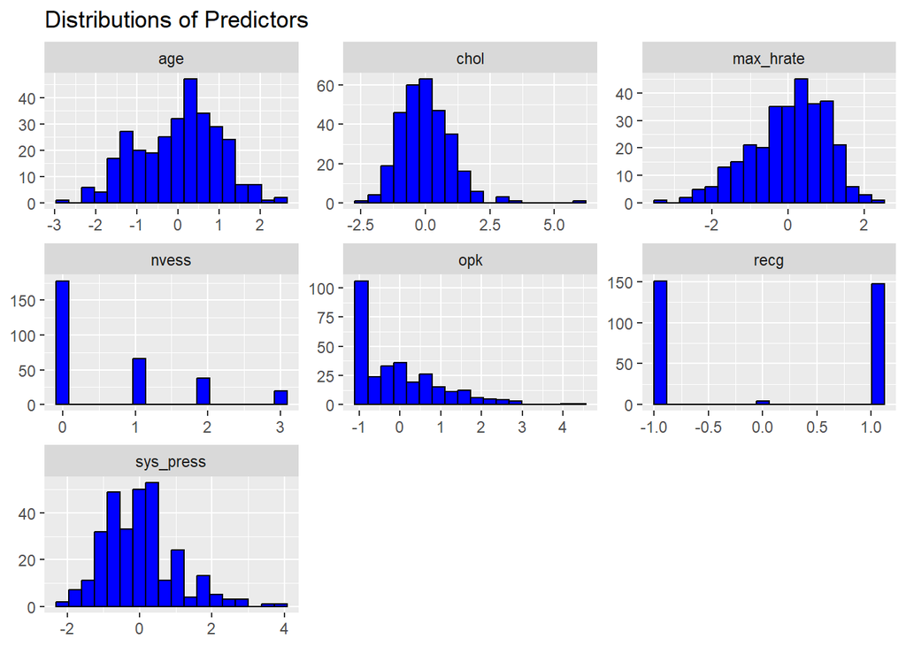

The report will now procede to determine the best single predictor.

## Part 3 - Visualizing a Logistic Model with One Predictor:

##### Determining the best predictor:

The following visualizations illustrate two predictors at the same time to prove whether they separate the response variable well, or not.

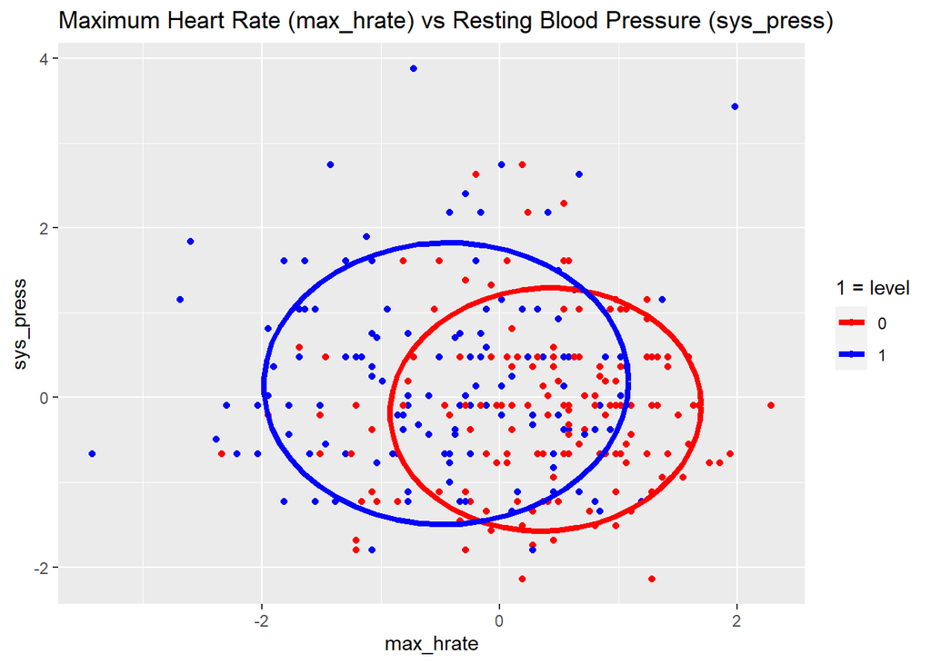

By looking at the graphs, the report can determine that the possible best predictors were **max_hrate** and **sys_press**, however, it is possible to observe that **max_hrate** separates the levels of heart disease absent (0) or present (1).

The report will present another perspective by using **age** instead of **sys_press**.

[figure not shown]

Once again, it is possible to observe the importance of **max_hrate**.

##### Logistic Model with One Predictor:

The report will now display a visualization of the results accompanied by the intercept and predictor.

```
## (Intercept)   max_hrate
##  -0.1622701  -0.9946601
```

[figure not shown]

```
##    y_hat_glm
##       0   1
##   0 128  35
##   1  56  83
```

## Conclusion:

It is possible to now understand that the **max_hrate** variable may not be enough to understand whether a heart disease is present or absent due to several misclassifications that can be observed in the previous Logistics Model.